# Variables asociadas a los fallecimientos por Covid-19. Año 2020-2021, Región AMBA

Ariana Bardauil, Sabrina Ibarra García, Micaela Zapata

23/9/2021

## 1.**Introducción**

En el año 2020 una fuerte crisis sanitaria se originó por la aparición del virus SARCOV-2 y la propagación de la pandemia del COVID-19.Esta pandemia afecto la vida y la salud de la población a nivel mundial.En Argentina se han tomado diferentes medidas de aislamiento social pero, a pesar de ello, una buena parte de la población ha sido afectada, alcanzando más de *100.000* casos de personas fallecidas.En este marco, nos interesa conocer quienes han sido las personas más vulnerables al no poder su superar la enfermedad, y encontrar algunas de las variables que podrían haber influido en su deceso.Se analizarán los factores que puedan afectar la tasa de fallecidos por *COVID-19* (calculada en relación al total de casos de personas contagiadas en diferentes localidades del AMBA). Se utilizará la base pública provista por el Ministerio de Salud de la Nación, sobre la situación de la COVID-19, disponible en: https://datos.gob.ar/dataset/salud-covid-19-casos-registrados-republica-argentina/archivo/salud_fd657d02-a33a-498b-a91b-2ef1a68b8d16.

Esta base contiene información de actualización diaria, notificando CASOS COVID-19 registrados en el país. La fecha de descarga de la base es 11 de agosto de 2021 con un corte a las 17:45 hs.Se indagará cómo está compuesta la base, sus dimensiones y los tipos de valores que conforman cada variable. La misma se delimitará y transformará para poder trabajarla, dado que se trata de un data set de grandes dimensiones. Para la etapa analítica, se generará una regresión, evaluando la medida en que diferentes variables independientes afectaron a esa tasa y se explorarán como tales: la edad, el sexo, si la persona fue internada en cuidados intensivos o no, si tuvo asistencia respiratoria o no y si fue atendida en el sistema público o privado de salud. Como variable dependiente, se calculará la tasa de letalidad por cada jurisdicción del AMBA, como resultado del cociente de personas que han fallecido en relación a las personas que se han contagiado, multiplicado por 100. Se analizarán modelos multivariados de efectos fijos y se evaluará la capacidad explicativa de sus diferentes variables y sus interacciones.

## 2. **Estructura de los datos**

La base covid-19 cuenta con *25* variables y *16.552.542* registros en total. Para posibilitar su procesamiento, se reducirá el análisis a los casos clasificados como “confirmados”. **Eso reduce la cantidad de registros a 2.497.319**. Una vez establecido este recorte, se trabajará sobre los casos correspondientes al AMBA, lo que **devuelve una base de 1.360.663 registros**. Iniciamos la preparación de la base.

```r
# Código de reducción de la base:
# covid_confirmados <- covid %>%
#   filter(clasificacion_resumen == "Confirmado",
#          residencia_provincia_nombre %in% c("Buenos Aires", "CABA"))

# Posteriormente se grabó la nueva base dentro del R Proyect para poder trabajar directamente sobre ella y ahorrar costo de procesamiento:

# readr::write_csv(covid_confirmados,
#                  'covid_confirmados.csv')
```

```r
# Llamado a la base de casos confirmados
covid_confirmados <- read_csv("covid_confirmados.csv")
```

Como parte del análisis exploratorio, hemos observado que las variables de la base, son:

| **Título de la Columna** | **Tipo de dato** | **Descripción** |
| --- | --- | --- |
| *id_evento_caso* | integer | Número de caso |
| *sexo* | String | Sexo |
| *edad* | Numero entero | Edad |
| *edad_años_meses* | String | Edad indicada en meses o años |
| *residencia_pais_nombre* | string | pais de residencia |
| *residencia_provincia_nombre* | string | Provincia de residencia |
| *residencia_departamento_nombre* | string | Departamento de residencia |
| *carga_Provincia_nombre* | string | Provincia de establecimiento |
| *fecha_inicio_sintomas* | Fecha ISO-8601(date) | Fecha de inicio de sintomas |
| *fecha_Apertura* | Fecha ISO-8601(date) | Fecha de apertura del caso |
| *sepi_Apertura* | Integer | Semana Epidemiológica de fecha de apertura |
| *fecha_internacion* | Fecha ISO-8601 (date) | Fecha de internación |
| *cuidado_intensivo* | string | Indicación si estuvo en cuidado intensivo |
| *fecha_cui_intensivo* | Fecha ISO-8601 (date) | Fecha de ingreso a cuidado intensivo en el caso de corresponder |
| *fallecido* | string | Indicacion de Fallecido |
| *fecha_fallecimiento* | Tiempo ISO-8601 (time) | Fecha de fallecimiento en el caso de corresponder |
| *asistencia_respiratoria_mecanica* | string | Indicación si requirió asistencia respiratoria mecánica |
| *carga_provincia_id* | integer | Código de Provincia de carga |
| *origen_financiamiento* | string | Origen de financiamiento |
| *Clasificacion* | string | Clasificacion manual del registro |
| *clasificacion_resumen* | string | clasificacion del caso |
| *residencia_provincia_id* | integer | Codigo de Provincia de Residencia |
| *fecha_diagnostico* | Tiempo ISO-8601 (time) | Fecha de diagnóstico |
| *residencia_departamento_id* | integer | Codigo departamento de residencia |

Empezamos por delimitar las localidades con las que sí queremos trabajar, y que pertenecen al AMBA.

```r
confirmados_AMBA_filtro <- covid_confirmados %>%
  filter(residencia_departamento_nombre  %in% c('Almirante Brown',
                                                'Avellaneda', 'Berazatagui'
                                                , 'Berisso', 'Brandsen',
                                                'Campana', 'Ca?uelas', 'Ensenada'
                                                , 'Escobar', 'Esteban Echeverr?a',
                                                'Exaltaci?n de la Cruz',
                                                'Ezeiza', 'Florencio Varela',
                                                'General Las Heras',
                                                'General Rodr?guez',
                                                'General San Mart?n',
                                                'Hurlingham', 'Ituzaing?',
                                                'Jos? C. Paz', 'La Matanza',
                                                'Lan?s', 'La Plata',
                                                'Lomas de Zamora',
                                                'Luj?n', 'Marcos Paz',
                                                'Malvinas Argentinas',
                                                'Moreno', 'Merlo', 'Mor?n',
                                                'Pilar', 'Presidente Per?n',
                                                'Quilmes', 'San Fernando',
                                                'San Isidro',
                                                'San Miguel', 'San Vicente',
                                                'Tigre', 'Tres de Febrero',
                                                'Vicente L?pez','Z?rate',
                                                'COMUNA 01', 'COMUNA 02',
                                                'COMUNA 03' ,'COMUNA 04',
                                                'COMUNA 05','COMUNA 06','COMUNA 07',
                                                'COMUNA 08', 'COMUNA 09', 'COMUNA 10'
                                                ,'COMUNA 11', 'COMUNA 12', 'COMUNA 13','COMUNA 14', 'COMUNA 15'))
```

Luego eliminamos los casos en que la localidad no ha sido especificada, y unificamos las comunas bajo el nombre “CABA”, dejando el resto de las localidades con su nombre y seleccionamos las variables que vamos a usar.

```r
confirmados_para_trabajar <- confirmados_AMBA_filtro %>%
  filter(!residencia_departamento_nombre == "SIN ESPECIFICAR") %>%
  mutate(localidad = case_when(residencia_departamento_nombre %in%
                                 c('COMUNA 01', 'COMUNA 02',
                                   'COMUNA 03' ,'COMUNA 04',
                                   'COMUNA 05','COMUNA 06','COMUNA 07',
                                   'COMUNA 08', 'COMUNA 09', 'COMUNA 10',
                                   'COMUNA 11', 'COMUNA 12', 'COMUNA 13','COMUNA 14', 'COMUNA 15') ~ "CABA",
                               TRUE ~ as.character(residencia_departamento_nombre))) %>%
    select(localidad,residencia_departamento_nombre, edad, sexo, origen_financiamiento,
         asistencia_respiratoria_mecanica, cuidado_intensivo, fecha_internacion,
         sepi_apertura, fallecido,origen_financiamiento,fecha_apertura)
```

Exploramos el sub set de datos que generamos:

```r
summary(confirmados_para_trabajar)
```

```
##   localidad         residencia_departamento_nombre      edad
##  Length:1360663     Length:1360663                 Min.   :-14.00
##  Class :character   Class :character               1st Qu.: 27.00
##  Mode  :character   Mode  :character               Median : 37.00
##                                                    Mean   : 39.46
##                                                    3rd Qu.: 50.00
##                                                    Max.   :221.00
##                                                    NA's   :465
##      sexo           origen_financiamiento asistencia_respiratoria_mecanica
##  Length:1360663     Length:1360663        Length:1360663
##  Class :character   Class :character      Class :character
##  Mode  :character   Mode  :character      Mode  :character
##
##
##
##
##  cuidado_intensivo  fecha_internacion    sepi_apertura    fallecido
##  Length:1360663     Min.   :2020-03-01   Min.   : 1.00   Length:1360663
##  Class :character   1st Qu.:2020-07-26   1st Qu.:15.00   Class :character
##  Mode  :character   Median :2020-10-09   Median :22.00   Mode  :character
##                     Mean   :2020-11-23   Mean   :24.05
##                     3rd Qu.:2021-04-18   3rd Qu.:32.00
##                     Max.   :2021-08-11   Max.   :53.00
##                     NA's   :1299258
##  fecha_apertura
##  Min.   :2020-03-02
##  1st Qu.:2020-09-29
##  Median :2021-03-26
##  Mean   :2021-02-01
##  3rd Qu.:2021-05-14
##  Max.   :2021-08-11
##
```

```r
str(confirmados_para_trabajar)
```

```
## tibble [1,360,663 x 11] (S3: tbl_df/tbl/data.frame)
##  $ localidad                       : chr [1:1360663] "CABA" "CABA" "Quilmes" "Florencio Varela" ...
##  $ residencia_departamento_nombre  : chr [1:1360663] "COMUNA 09" "COMUNA 09" "Quilmes" "Florencio Varela" ...
##  $ edad                            : num [1:1360663] 73 42 54 44 48 53 8 20 25 49 ...
##  $ sexo                            : chr [1:1360663] "F" "F" "M" "F" ...
##  $ origen_financiamiento           : chr [1:1360663] "Público" "Público" "Privado" "Privado" ...
##  $ asistencia_respiratoria_mecanica: chr [1:1360663] "NO" "NO" "NO" "NO" ...
##  $ cuidado_intensivo               : chr [1:1360663] "NO" "NO" "NO" "NO" ...
##  $ fecha_internacion               : Date[1:1360663], format: NA NA ...
##  $ sepi_apertura                   : num [1:1360663] 14 14 14 14 14 14 23 14 14 14 ...
##  $ fallecido                       : chr [1:1360663] "NO" "NO" "SI" "NO" ...
##  $ fecha_apertura                  : Date[1:1360663], format: "2021-04-08" "2021-04-08" ...
```

```r
skim(confirmados_para_trabajar)
```

Data summary

| Name | confirmados_para_trabajar |
| --- | --- |
| Number of rows | 1360663 |
| Number of columns | 11 |
| _______________________ |  |
| Column type frequency: |  |
| character | 7 |
| Date | 2 |
| numeric | 2 |
| ________________________ |  |
| Group variables | None |

**Variable type: character**

| skim_variable | n_missing | complete_rate | min | max | empty | n_unique | whitespace |
| --- | --- | --- | --- | --- | --- | --- | --- |
| localidad | 0 | 1 | 4 | 19 | 0 | 27 | 0 |
| residencia_departamento_nombre | 0 | 1 | 5 | 19 | 0 | 41 | 0 |
| sexo | 0 | 1 | 1 | 2 | 0 | 3 | 0 |
| origen_financiamiento | 0 | 1 | 7 | 7 | 0 | 2 | 0 |
| asistencia_respiratoria_mecanica | 0 | 1 | 2 | 2 | 0 | 2 | 0 |
| cuidado_intensivo | 0 | 1 | 2 | 2 | 0 | 2 | 0 |
| fallecido | 0 | 1 | 2 | 2 | 0 | 2 | 0 |

**Variable type: Date**

| skim_variable | n_missing | complete_rate | min | max | median | n_unique |
| --- | --- | --- | --- | --- | --- | --- |
| fecha_internacion | 1299258 | 0.05 | 2020-03-01 | 2021-08-11 | 2020-10-09 | 527 |
| fecha_apertura | 0 | 1.00 | 2020-03-02 | 2021-08-11 | 2021-03-26 | 527 |

**Variable type: numeric**

| skim_variable | n_missing | complete_rate | mean | sd | p0 | p25 | p50 | p75 | p100 | hist |
| --- | --- | --- | --- | --- | --- | --- | --- | --- | --- | --- |
| edad | 465 | 1 | 39.46 | 17.11 | -14 | 27 | 37 | 50 | 221 | ▆▇▁▁▁ |
| sepi_apertura | 0 | 1 | 24.05 | 12.04 | 1 | 15 | 22 | 32 | 53 | ▃▇▆▃▂ |

Dada la cantidad de valores missing en la variable “fecha_internacion”, se eliminará la variable del análisis. Eliminamos los NA y outliers de edad para seleccionar sólo las que están entre *-1* (bebes) y *105 años*. Eliminamos también las respuestas *“NR”* de la variable sexo (se trata de pocos registros).

```r
confirmados_para_trabajar <-confirmados_para_trabajar %>%
  filter (edad<105 & edad>-1)%>%
  drop_na(edad) %>%
  filter (sexo != 'NR')

# removemos data sets anteriores

rm(covid_confirmados)
rm(confirmados_AMBA_filtro)
```

## 3.**Análisis descriptivo**

Realizamos un análisis de las variables más relevantes, describiendo contagios y fallecimientos por edad, sexo y localidad.

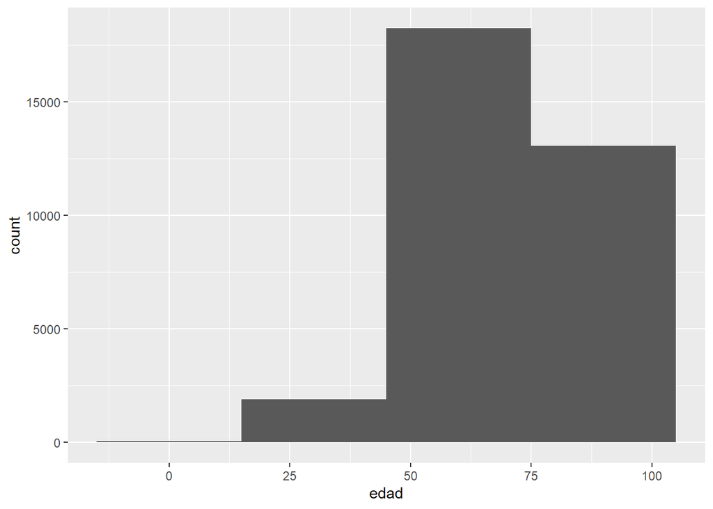

```r
# Fallecidos/as por edad
distribucion_fallecido_edad <- confirmados_para_trabajar %>%
  filter(fallecido == "SI") %>%
  ggplot(aes(x = edad)) +
  geom_histogram(binwidth = 30)
distribucion_fallecido_edad
```

```r
Fallecidos_agrupadosxedad <- confirmados_para_trabajar %>%
  filter(fallecido == "SI") %>%
  group_by(edad) %>%
  summarise(n = n()) %>%
  arrange(desc(n)) %>%
  head(10)
Fallecidos_agrupadosxedad
```

```
## # A tibble: 10 x 2
##     edad     n
##    <dbl> <int>
##  1    77   969
##  2    73   959
##  3    69   934
##  4    70   922
##  5    76   915
##  6    74   910
##  7    72   893
##  8    78   891
##  9    67   886
## 10    79   882
```

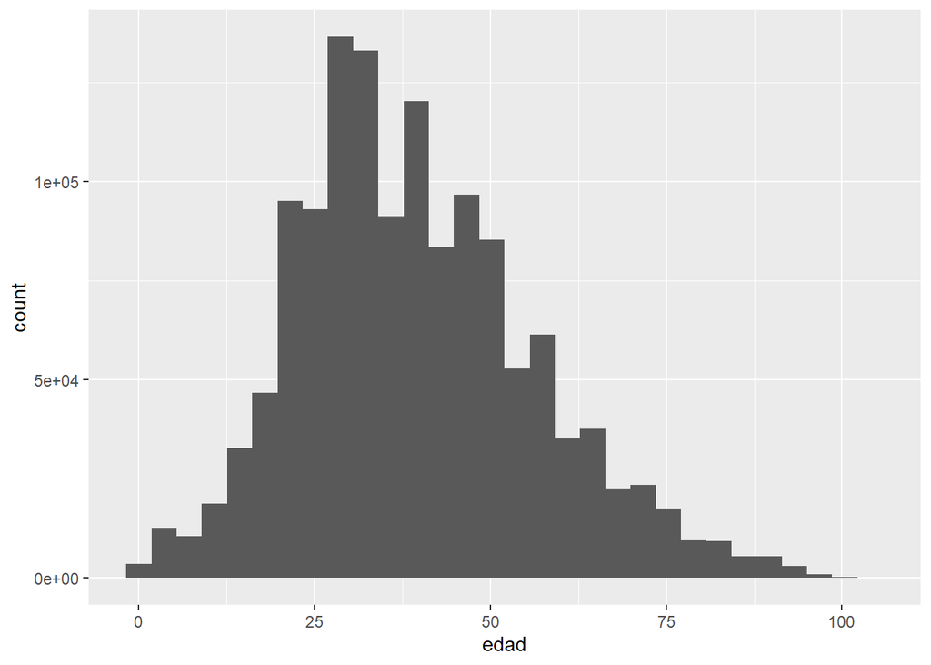

```r
distribucion_contagiados_edad <- confirmados_para_trabajar %>%
  ggplot(aes(x=edad)) +
  geom_histogram(bins = 30)
distribucion_contagiados_edad
```

```r
confirmados_agrupadosxedad <- confirmados_para_trabajar %>%
  group_by(edad) %>%
  summarise(n=n()) %>%
  arrange(desc(n)) %>%
  head(10)
confirmados_agrupadosxedad
```

```
## # A tibble: 10 x 2
##     edad     n
##    <dbl> <int>
##  1    29 34991
##  2    30 34980
##  3    31 33931
##  4    32 33766
##  5    28 33544
##  6    27 32917
##  7    33 32890
##  8    26 32660
##  9    34 32345
## 10    35 31670
```

```r
confirmados_agrupadosxlocalidad <- confirmados_para_trabajar %>%
  group_by(localidad) %>%
  summarise(n=n()) %>%
  arrange(desc(n)) %>%
  head(10)
confirmados_agrupadosxlocalidad
```

```
## # A tibble: 10 x 2
##    localidad            n
##    <chr>            <int>
##  1 CABA            244096
##  2 La Matanza      166506
##  3 Quilmes          80206
##  4 La Plata         80086
##  5 Lomas de Zamora  68490
##  6 Almirante Brown  67534
##  7 Merlo            58084
##  8 Moreno           56633
##  9 Pilar            51523
## 10 Tigre            48970
```

Se observa que **las localidades con mayor tasa de contagios son CABA y la Matanza**, seguidos por **La Plata y Quilmes**. No obstante, coinciden con ser las localidades de mayor población.

```r
Fallecidos_agrupadosxlocalidad <- confirmados_para_trabajar %>%
  filter(fallecido=="SI") %>%
  group_by(localidad) %>%
  summarise(n=n()) %>%
  arrange(desc(n)) %>%
  head(10)
Fallecidos_agrupadosxlocalidad
```

```
## # A tibble: 10 x 2
##    localidad           n
##    <chr>           <int>
##  1 La Matanza       4667
##  2 CABA             4172
##  3 La Plata         2502
##  4 Quilmes          2423
##  5 Almirante Brown  2105
##  6 Merlo            1719
##  7 Lomas de Zamora  1475
##  8 Avellaneda       1406
##  9 Tres de Febrero  1350
## 10 Moreno           1280
```

Las localidades con mayor **tasa de fallecidos**, conciden con las de mayores casos,pero el ranking es diferente siendo *La Matanza* la localidad con mayor cantidad de decesos, seguidos por *CABA, La Plata y Quilmes*. Cabe destacar que el salto que se produce entre las dos primeras es mucho menor que el que se observa en los contagiados.

Mientras que la brecha entre el 3er puesto y el 1ro en número de contagiados es del *30%*, entre las mismas localidades,la relación en la tasa de letalidad es del *56%*, lo que muestra que una mayor cantidad de contagio no se relaciona proporcionalmente con una mayor cantidad de fallecidos

Es por ello que en el trabajo vamos a analizar los factores que explican estas diferentes tasas de letalidad entre las localidades.

## 4.**Analizando las olas de contagio**

### 4.1 Semana epidemiologica para ver las olas de contagio

```r
confirmados_para_trabajar <- confirmados_para_trabajar %>%
  mutate(anio_c = year(fecha_apertura)) %>%
  mutate(anio = str_extract(anio_c, "\\d{2}$")) %>%
  mutate(sepi_apertura_c = case_when(sepi_apertura %in%
                                       c(1,2,3,4,5,6,7,8,9) ~ paste("0", sepi_apertura), TRUE ~ as.character(sepi_apertura)))%>%
  mutate(sepi_anio = paste(anio,sepi_apertura_c, sep = "."))%>%
  mutate(sepi_anio = paste(anio,sepi_apertura_c, sep = "_"))
```

### 4.2 ¿Cuales fueron las olas de mayores contagiados y fallecidos en el AMBA?

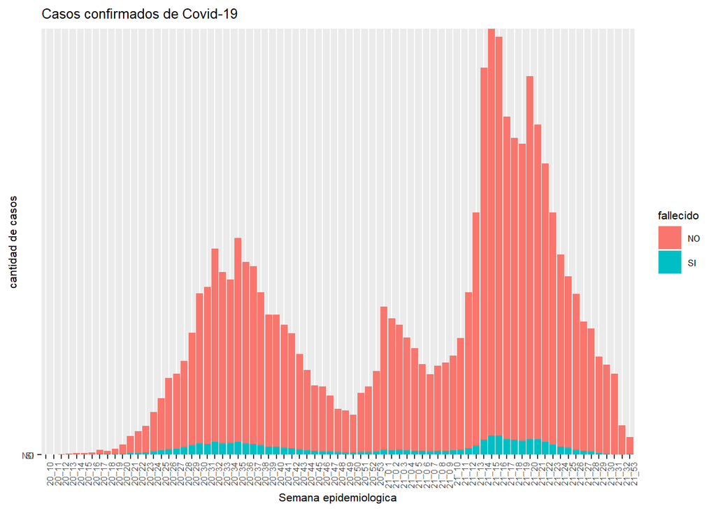

```r
confirmados_para_trabajar %>%
  group_by(sepi_anio, fallecido) %>%
  arrange(desc(sepi_anio)) %>%
  ggplot(aes(x=sepi_anio, y=fallecido, fill=fallecido)) +
  geom_col() +
  labs(title = "Casos confirmados de Covid-19",
       x = "Semana epidemiologica",
       y = "cantidad de casos") +
  theme(text = element_text(size=8),
        axis.text.x = element_text(angle=90, hjust=1))
```

```r
confirmados_xsemanaepi <- confirmados_para_trabajar%>%
  group_by(sepi_anio) %>%
  summarise(n=n()) %>%
  arrange(desc (n)) %>%
  head(10)
confirmados_xsemanaepi
```

```
## # A tibble: 10 x 2
##    sepi_anio     n
##    <chr>     <int>
##  1 21_15     59367
##  2 21_16     58209
##  3 21_14     54075
##  4 21_20     52854
##  5 21_17     47106
##  6 21_21     45902
##  7 21_18     44043
##  8 21_19     43292
##  9 21_22     40550
## 10 21_13     33911
```

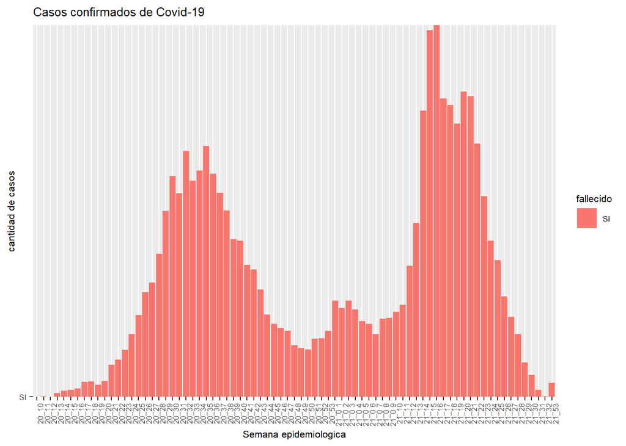

```r
confirmados_para_trabajar %>%
  filter (fallecido == "SI") %>%
  group_by(sepi_anio, fallecido) %>%
  arrange(desc(sepi_anio)) %>%
  ggplot(aes(x=sepi_anio, y = fallecido, fill = fallecido)) +
  geom_col() +
  labs(title = "Casos confirmados de Covid-19",
       x = "Semana epidemiologica",
       y = "cantidad de casos") +
  theme(text = element_text(size=8),
        axis.text.x = element_text(angle=90, hjust=1))
```

```r
fallecidos_xsemanaepi <- confirmados_para_trabajar %>%
  filter(fallecido == "SI") %>%
  group_by(sepi_anio) %>%
  summarise(n=n()) %>%
  arrange(desc (n)) %>%
  head(10)
fallecidos_xsemanaepi
```

```
## # A tibble: 10 x 2
##    sepi_anio     n
##    <chr>     <int>
##  1 21_16      1382
##  2 21_15      1363
##  3 21_20      1135
##  4 21_21      1118
##  5 21_17      1109
##  6 21_18      1085
##  7 21_14      1064
##  8 21_19      1015
##  9 21_22       941
## 10 20_35       932
```

La semana epidemiologia de mayor fallecimiento se dan entre *15 y 16* con más de *1300 fallecidos*. Esto se dio hacia principios de abril de este año (2021)

## 5.**Analisis de letalidad**

```r
# Calculamos Tasa de letalidad = fallecidos/nofallecidos*100
confirmados_AMBA_xdepto <- confirmados_para_trabajar %>%
  group_by(localidad, fallecido) %>%
  summarise (residencia = n()) %>%
  pivot_wider(names_from = fallecido, values_from = residencia) %>%
  mutate(ratio_fall_nofall = round(SI / NO,5)*100) %>%
  select(-SI, -NO)
```

### 5.1 ¿Cuáles son los municipios que han registrado la mayor tasa de letalidad?

```r
ranking_tasa_letalidad <- confirmados_AMBA_xdepto %>%
  arrange(desc(ratio_fall_nofall))%>%
  head(10)
knitr::kable(ranking_tasa_letalidad)
```

| localidad | ratio_fall_nofall |
| --- | --- |
| La Plata | 3.225 |
| Almirante Brown | 3.217 |
| Hurlingham | 3.124 |
| Quilmes | 3.115 |
| San Fernando | 3.080 |
| Avellaneda | 3.052 |
| Merlo | 3.050 |
| Tres de Febrero | 3.031 |
| Berisso | 3.030 |
| La Matanza | 2.884 |

Al analizar la tasa de letalidad, aparecen como los municipios más impactados: *La Plata* con 3.225 fallecidos cada 100 contagiados, seguid por *Almirante Brown* con 3.217 y *Hurlingham*, con 3.124. CABA sale del ranking de los municipios más afectados, lo que muestra que, a pesar de la mayor cantidad de contagiados y fallecidos en esta localidad, la tasa de letalidad ha sido baja en relación a otras. Las más afectadas - en términos de cantidad de personas fallecidas - en pandemia han sido *La Matanza* y *CABA*. Sin embargo, localidades como *Almirante Brown* y *Hurlingham* presentan una mayor tasa de letalidad, resultando mayormente afectadas por la pandemia.

## 6.**Armando la Regresión**

```r
covid_confirmados_pararegresion <- confirmados_para_trabajar %>%
  group_by(localidad) %>%
  summarise(edad_promedio = mean(edad,na.rm=TRUE),
            Q_M=sum(sexo == "F")/n(),
            Q_H=sum(sexo == "M")/n(),
            ratioM_H = sum(sexo == "F")/sum(sexo == "M"),
            Q_respirador = sum(asistencia_respiratoria_mecanica == "SI"),
            Q_fin_privado = sum(origen_financiamiento == "Privado"),
            Q_fin_publico = sum(origen_financiamiento == "Público"),
            Q_cuidadoIntensivo = sum(cuidado_intensivo == "SI"))


base_regresion_final <- covid_confirmados_pararegresion %>%
  left_join(confirmados_AMBA_xdepto, by = "localidad")


modelo_lineal <- base_regresion_final %>%
  lm(ratio_fall_nofall ~ edad_promedio + ratioM_H + Q_fin_privado + Q_fin_publico + Q_respirador + Q_cuidadoIntensivo , .)

summary(modelo_lineal)
```

```
##
## Call:
## lm(formula = ratio_fall_nofall ~ edad_promedio + ratioM_H + Q_fin_privado +
##     Q_fin_publico + Q_respirador + Q_cuidadoIntensivo, data = .)
##
## Residuals:
##      Min       1Q   Median       3Q      Max
## -0.71530 -0.18244  0.03584  0.23480  0.51741
##
## Coefficients:
##                      Estimate Std. Error t value Pr(>|t|)
## (Intercept)        -1.133e+01  3.838e+00  -2.952 0.007888 **
## edad_promedio       3.560e-01  8.787e-02   4.052 0.000624 ***
## ratioM_H            1.599e-02  2.443e+00   0.007 0.994844
## Q_fin_privado       2.661e-06  1.272e-05   0.209 0.836345
## Q_fin_publico       9.873e-07  1.312e-05   0.075 0.940757
## Q_respirador        9.128e-04  2.251e-03   0.405 0.689478
## Q_cuidadoIntensivo -9.505e-04  1.529e-03  -0.622 0.541142
## ---
## Signif. codes:  0 '***' 0.001 '**' 0.01 '*' 0.05 '.' 0.1 ' ' 1
##
## Residual standard error: 0.3816 on 20 degrees of freedom
## Multiple R-squared:  0.5523, Adjusted R-squared:  0.4181
## F-statistic: 4.113 on 6 and 20 DF,  p-value: 0.007531
```

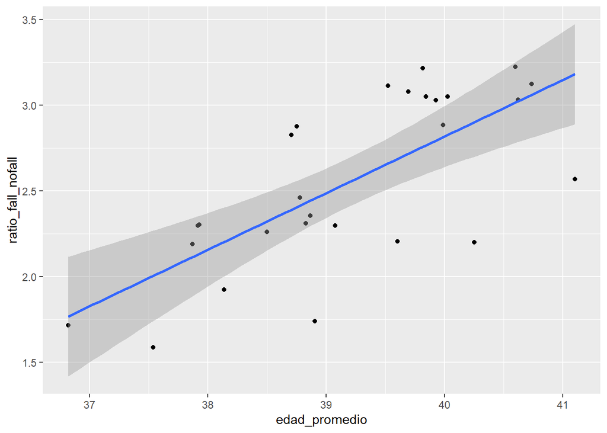

```r
base_regresion_final %>%
  ggplot(aes(x = edad_promedio, y = ratio_fall_nofall)) +
  geom_point() +
  geom_smooth(method = lm)
```

Se intentó analizar el fecto de la variable sexo en el total de infectados/as, pero el modelo mostró multicolinealidad entre las variables. Esta variable fue reemplazada por el ratio mujer/hombre.

La tasa de letalidad por municipio esta asociada a la edad de las personas contagiadas pero no guarda relación con el resto de las variables. Los resultados indican que la tasa de letalidad por municipio aumenta en **0,36** puntos cuando aumenta en un año la edad del infectado.

Retomando lo visto anteriormente, los municipios con mayor tasa de letalidad serán aquellos que presenten una población de infectados más envejecida.  
El $R^2$ ajustado indica que el modelo explica el *40%* de las observaciones con un F significativo.

En un segundo modelo, se probará el análisis interactuando la edad y el sexo de los infectados.

```r
modelo_lineal_2 <- base_regresion_final %>%
  lm(ratio_fall_nofall ~ edad_promedio + ratioM_H + Q_respirador + Q_cuidadoIntensivo + ratioM_H * edad_promedio, .)

summary(modelo_lineal_2)
```

```
##
## Call:
## lm(formula = ratio_fall_nofall ~ edad_promedio + ratioM_H + Q_respirador +
##     Q_cuidadoIntensivo + ratioM_H * edad_promedio, data = .)
##
## Residuals:
##      Min       1Q   Median       3Q      Max
## -0.76037 -0.18825  0.05432  0.23577  0.54377
##
## Coefficients:
##                          Estimate Std. Error t value Pr(>|t|)
## (Intercept)             2.830e+01  7.338e+01   0.386    0.704
## edad_promedio          -6.437e-01  1.862e+00  -0.346    0.733
## ratioM_H               -4.085e+01  7.518e+01  -0.543    0.593
## Q_respirador            9.930e-04  1.963e-03   0.506    0.618
## Q_cuidadoIntensivo     -8.282e-04  1.274e-03  -0.650    0.523
## edad_promedio:ratioM_H  1.031e+00  1.906e+00   0.541    0.594
##
## Residual standard error: 0.3704 on 21 degrees of freedom
## Multiple R-squared:  0.5573, Adjusted R-squared:  0.4519
## F-statistic: 5.287 on 5 and 21 DF,  p-value: 0.002683
```

En el caso del segundo modelo, los resultados muestran que ninguna de las variables incoporadas son significativas.

Elaboramos un tercer modelo en el que se incorporará una interacción entre la edad promedio y la internación en cuidados intensivos.

```r
modelo_lineal_3 <- base_regresion_final %>%
  lm(ratio_fall_nofall ~ edad_promedio + ratioM_H + Q_respirador + Q_cuidadoIntensivo +
       Q_cuidadoIntensivo * edad_promedio, .)

summary(modelo_lineal_3)
```

```
##
## Call:
## lm(formula = ratio_fall_nofall ~ edad_promedio + ratioM_H + Q_respirador +
##     Q_cuidadoIntensivo + Q_cuidadoIntensivo * edad_promedio,
##     data = .)
##
## Residuals:
##      Min       1Q   Median       3Q      Max
## -0.71680 -0.16299  0.01177  0.22881  0.56867
##
## Coefficients:
##                                    Estimate Std. Error t value Pr(>|t|)
## (Intercept)                      -8.1224269  4.0390193  -2.011  0.05734 .
## edad_promedio                     0.2849931  0.0920038   3.098  0.00545 **
## ratioM_H                         -0.4269601  2.1133577  -0.202  0.84184
## Q_respirador                      0.0017043  0.0019900   0.856  0.40143
## Q_cuidadoIntensivo               -0.0141946  0.0102864  -1.380  0.18212
## edad_promedio:Q_cuidadoIntensivo  0.0003299  0.0002509   1.315  0.20274
## ---
## Signif. codes:  0 '***' 0.001 '**' 0.01 '*' 0.05 '.' 0.1 ' ' 1
##
## Residual standard error: 0.3585 on 21 degrees of freedom
## Multiple R-squared:  0.5853, Adjusted R-squared:  0.4865
## F-statistic: 5.927 on 5 and 21 DF,  p-value: 0.001439
```

La interacción entre edad y el haber estado en cuidados intensivos, no es significativa. Es decir, la tasa de letalidad por municipio no cambia si en el municipio hay más personas de mayor edad internadas en cuidados intensivos. La edad promedio sigue presentándose como una variable significativa.

En un cuarto modelo, se incopora la interacción entre los cuidados intensivos y el ratio hombre/mujer.

```r
modelo_lineal_4 <- base_regresion_final %>%
  lm(ratio_fall_nofall ~ edad_promedio + ratioM_H + Q_respirador + Q_cuidadoIntensivo  +  Q_cuidadoIntensivo * ratioM_H,.)

summary(modelo_lineal_4)
```

```
##
## Call:
## lm(formula = ratio_fall_nofall ~ edad_promedio + ratioM_H + Q_respirador +
##     Q_cuidadoIntensivo + Q_cuidadoIntensivo * ratioM_H, data = .)
##
## Residuals:
##      Min       1Q   Median       3Q      Max
## -0.70373 -0.17149  0.01547  0.22992  0.50111
##
## Coefficients:
##                               Estimate Std. Error t value Pr(>|t|)
## (Intercept)                 -1.218e+01  3.471e+00  -3.509 0.002088 **
## edad_promedio                3.491e-01  7.481e-02   4.667 0.000132 ***
## ratioM_H                     1.150e+00  2.838e+00   0.405 0.689478
## Q_respirador                 9.615e-04  1.944e-03   0.495 0.625966
## Q_cuidadoIntensivo           2.812e-03  5.042e-03   0.558 0.582866
## ratioM_H:Q_cuidadoIntensivo -3.578e-03  4.880e-03  -0.733 0.471581
## ---
## Signif. codes:  0 '***' 0.001 '**' 0.01 '*' 0.05 '.' 0.1 ' ' 1
##
## Residual standard error: 0.3683 on 21 degrees of freedom
## Multiple R-squared:  0.5623, Adjusted R-squared:  0.4581
## F-statistic: 5.396 on 5 and 21 DF,  p-value: 0.002407
```

La interacción incorporada en el modelo 4 tampoco representa un efecto significativo en la tasa de letalidad.

En un quinto modelo, se incorpora la interacción entre haber pasado por UCI y haber tenido asistencia respiratoria mecánica.

```r
modelo_lineal_5 <- base_regresion_final %>%
  lm(ratio_fall_nofall ~ edad_promedio + ratioM_H + Q_respirador + Q_cuidadoIntensivo +
       + Q_cuidadoIntensivo * Q_respirador, .)

summary(modelo_lineal_5)
```

```
##
## Call:
## lm(formula = ratio_fall_nofall ~ edad_promedio + ratioM_H + Q_respirador +
##     Q_cuidadoIntensivo + +Q_cuidadoIntensivo * Q_respirador,
##     data = .)
##
## Residuals:
##      Min       1Q   Median       3Q      Max
## -0.70902 -0.17446  0.01516  0.19781  0.40379
##
## Coefficients:
##                                   Estimate Std. Error t value Pr(>|t|)
## (Intercept)                     -9.682e+00  3.063e+00  -3.161  0.00471 **
## edad_promedio                    2.929e-01  7.224e-02   4.055  0.00057 ***
## ratioM_H                         6.994e-01  1.996e+00   0.350  0.72950
## Q_respirador                     3.611e-03  2.118e-03   1.705  0.10296
## Q_cuidadoIntensivo              -1.381e-03  1.173e-03  -1.178  0.25203
## Q_respirador:Q_cuidadoIntensivo -8.201e-07  3.559e-07  -2.304  0.03152 *
## ---
## Signif. codes:  0 '***' 0.001 '**' 0.01 '*' 0.05 '.' 0.1 ' ' 1
##
## Residual standard error: 0.3332 on 21 degrees of freedom
## Multiple R-squared:  0.6417, Adjusted R-squared:  0.5564
## F-statistic: 7.523 on 5 and 21 DF,  p-value: 0.0003489
```

### 6.1 Comparando el modelo 1 y 5:

Además, si comparamos los residuos de ambos modelos, vemos que en el *modelo 5*, los mismos se concentran más en torno al 0, a diferencia del modelo uno.

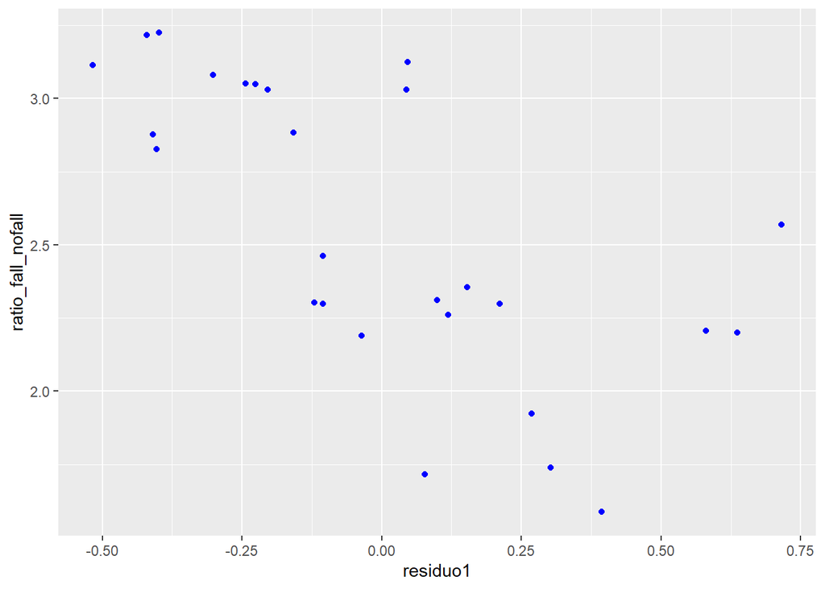

```r
# Análisis gráfico de los residuos modelos 1 y 5.

base_regresion_final %>%
  mutate(residuo1 = (predict.lm(modelo_lineal) - base_regresion_final$ratio_fall_nofall)) %>%
  ggplot(aes(x = residuo1, y = ratio_fall_nofall)) +
  geom_point(color = "blue")
```

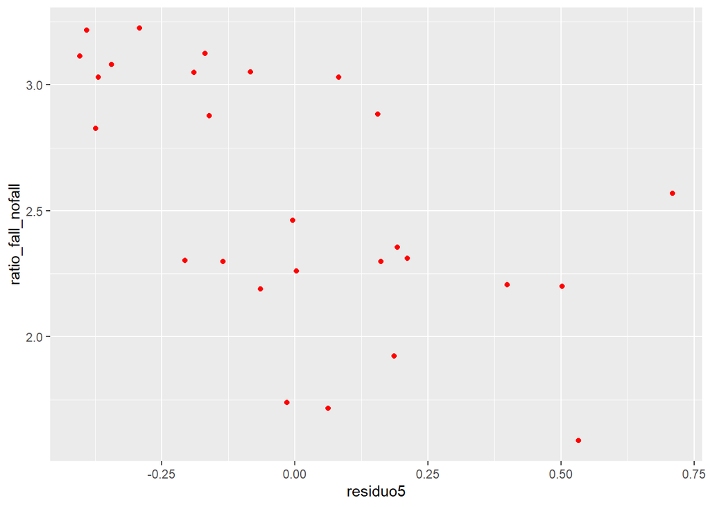

```r
base_regresion_final %>%
  mutate(residuo5 = (predict.lm(modelo_lineal_5)-base_regresion_final$ratio_fall_nofall)) %>%
  ggplot(aes(x = residuo5, y = ratio_fall_nofall)) +
  geom_point(color = "red")
```

### 6.2 Algunas predicciones:

Estos datos muestran que una estrategia más eficiente para aminorar la letalidad de la enfermedad es el cuidado de las personas mayores, que son las más vulnerables. Son pocos los cambios que se pueden lograr en reducir la letalidad, aumentando las camas de cuidado intensivo y la asistencia respiratoria. De ello, puede suponerse que la edad - y con ella los factores de riesgo - son más importantes, y una vez avanzada la enfermedad la posibilidad de sobrevivir habiendo llegado a necesitar asistencia respiratoria mecánica, son bajas.

## 7.**Conclusiones**

La tasa de letalidad solo depende positivamente de la edad de las personas, y negativamente por haber estado internado en cuidados intensivos con respirador. Las internaciones en cuidados intensivos sin asistencia respiratoria no cambian la tasa de letalidad de los municipios, al igual que no hay diferencia entre el género de las personas. Tampoco se distinguen diferencias en la letalidad entre las asistencias provistas por el sistema público o privado.

Por lo tanto, la edad es el factor clave que explica la tasa de letalidad de los municipios, y la internación con asistencia repiratoria mecánica tiende a reducirla de manera poco significativa.